# Fun with maps in R!

Emily O’Dean

7/16/2018

#### NCEAS Hacky Hour 2018-07-16

For this week’s hacky hour, we’ll look at a few tools for making pretty maps in R. In order to best understand and participate in this hacky hour, you should have some knowledge of the `ggplot2` library in R, and a basic knowledge of spatial data.

Here’s a couple of great R/spatial tutorials using a couple of different packages.

[simple features and ggplot2](http://strimas.com/r/tidy-sf/)  
[tmap, ggplot2, leaflet](https://github.com/Robinlovelace/Creating-maps-in-R)  
[reproducible maps in R](http://eriqande.github.io/rep-res-web/lectures/making-maps-with-R.html)

The [`sasap-maps`](https://github.nceas.ucsb.edu/NCEAS/sasap-maps) repo also has some great examples of making maps with `sf` and `ggplot2`.

### Hacky hour exercise

Find and download some data you’d like to visualize, or use and expand on the example below.

[ESRI Open Data](https://hub.arcgis.com/pages/open-data)  
[US Gov’s Open Data](https://www.data.gov/)

#### Example exploratory mapping

I’m going to download some wildfire data from [USGS](https://www.sciencebase.gov/catalog/item/59667039e4b0d1f9f05cf2ff) depicting wildfire borders over the last century

```r
library(ggmap)
library(ggplot2)
library(sf)
library(tigris) # remotes::install_github('walkerke/tigris')

fires <- "/Users/datateam/Downloads/Wildfires_1870_2015_Great_Basin_SHAPEFILE/Wildfires_1870_2015_Great_Basin.shp"
fires_shp <- st_read(fires)

# tigris has this function which will allow us to load in a basemap as a simple feature
usa <- states(class = "sf") %>% st_crop(c(xmin = -100, xmax = -130, ymin = 32, ymax = 48))

# check the projections of each simple feature to make sure that they're consistent (info about reprojecting can be found in SF's vignette)
st_crs(usa)
st_crs(fires_shp)
```

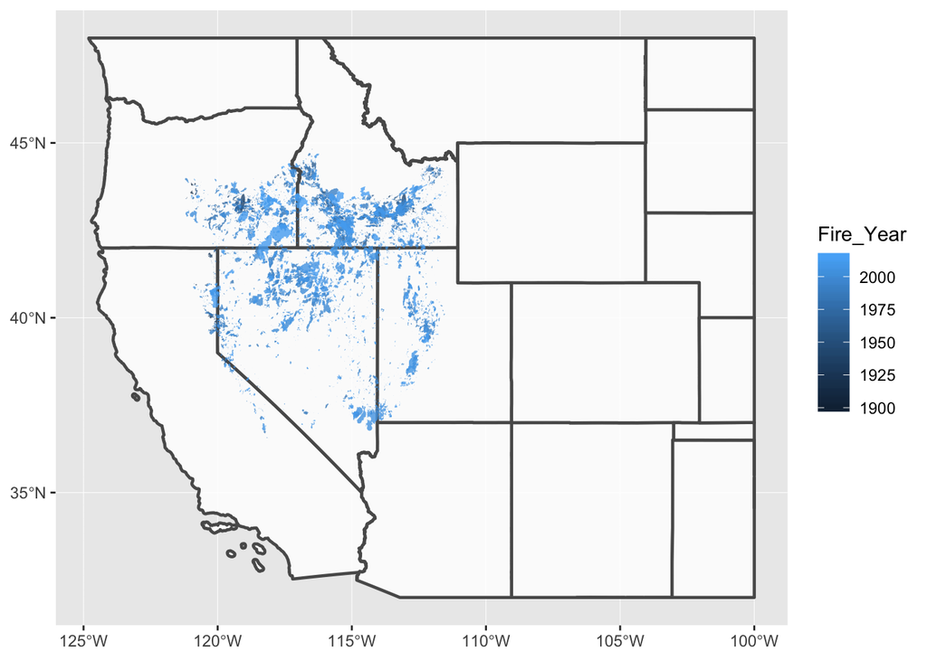

```r
fire_map <- ggplot() +
  geom_sf(data=usa, fill="white", lwd = 0.8, alpha=0.8) +
  geom_sf(data=fires_shp, aes(fill = Fire_Year), lwd = 0.0, alpha=0.8)

print(fire_map)
```

There’s obviously a lot we can do to improve this map. Here’s some things to play around with

- Improve the crop on the map
- Add labels for the name of the fire
- Change the colors on the map
- Group by decade to reduce noise
- Play around with borders/transparency in case there are overlapping fires
- Try making a dynamic map with the `tmap` package or leaflet